# Machine Learning Course Project

Thijs Cornelissen

June 8, 2016

A model was built to predict the activity of a subject based on measurements from accelerometers. After training and optimizing a support vector machine, the performance was estimated using a test set. The estimated accuracy is 99.3%, with a 95% confidence interval of (99.0%, 99.5%).

## Data Processing

First we fix the random seed, such that the results in this report are reproducible.

```r
library(caret)
library(e1071)
set.seed(123)
```

Now we load the training data set. We remove the columns where more than 95% of the entries are missing.

```r
data<-read.csv("pml-training.csv",na.strings=c("NA","","#DIV/0!"))
isna<-apply(data,2,FUN=function(x) sum(is.na(x))/length(x))
data<-data[,-which(isna>.95)]
```

We use the `nearZeroVar` function to remove the variables with little or no variability.

```r
removeidx<-nearZeroVar(data)
data<-data[,-removeidx]
```

We also remove the variables corresponding to subject name and time, as we do not want to train on those variables.

```r
data<-data[,-c(1,2,3,4,5)]
```

Now we split the data set into three pieces: a training set (60%) to train our models, a cross-validation set (20%) to assess and optimize the performance of the model, and a testing set (20%) to estimate the final performance.

```r
inTrain<-createDataPartition(y=data$classe,p=0.6,list=FALSE)
training<-data[inTrain,]
testing<-data[-inTrain,]
incv<-createDataPartition(y=testing$classe,p=0.5,list=FALSE)
crossval<-testing[incv,]
testing<-testing[-incv,]
```

## Results

Now we will build and test our model. Three methods were tested: random forests, boosted trees, and support vector machines (SVM). The SVM clearly gave the best performance out of the box, with an accuracy of around 95%. The random forest and boosted accuracies were much lower at around 80%, and also took much more time to train. We will only show results obtained with the SVM in this report.

To assess and optimize the performance of the SVM, we will plot the learning curve, i.e. the accuracy as a function of the number of samples used to train the model. We do this for two separate cases: one where all parameters are left at their default values, and one where the `cost` parameter is set to 100 instead of 1 (the default). Higher values of `cost` allow the SVM to build more complex prediction functions.

```r
samplefrac<-seq(0.1,1,0.1)
trainacc<-c()
cvacc<-c()
trainacc2<-c()
cvacc2<-c()
for (i in samplefrac) {
   insub<-createDataPartition(y=training$classe,p=i,list=FALSE)
   subtrain<-training[insub,]
   modelfit<-svm(subtrain$classe~.,data=subtrain)
   trainacc<-c(trainacc,sum(predict(modelfit,subtrain)==subtrain$classe)/nrow(subtrain))
   cvacc<-c(cvacc,sum(predict(modelfit,crossval)==crossval$classe)/nrow(crossval))
   modelfit<-svm(subtrain$classe~.,data=subtrain,cost=100)
   trainacc2<-c(trainacc2,sum(predict(modelfit,subtrain)==subtrain$classe)/nrow(subtrain))
   cvacc2<-c(cvacc2,sum(predict(modelfit,crossval)==crossval$classe)/nrow(crossval))
}
```

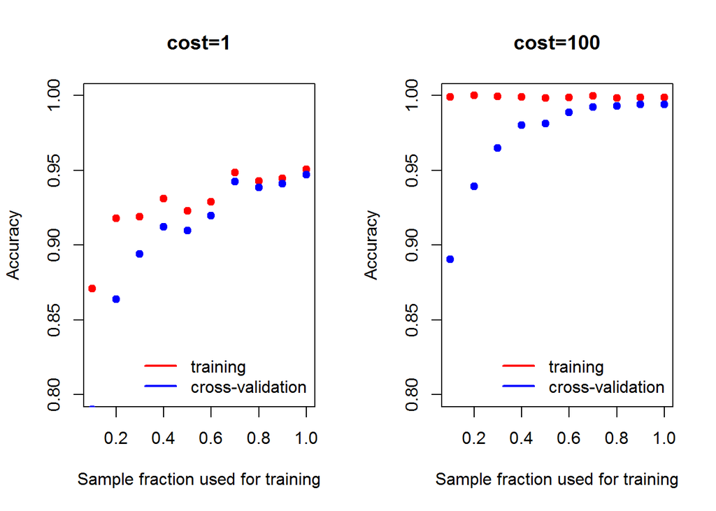

```r
par(mfrow=c(1,2))

plot(samplefrac,trainacc,ylim=c(0.8,1),xlab="Sample fraction used for training",ylab="Accuracy",col="red",pch=19,main="cost=1")
points(samplefrac,cvacc,col="blue",pch=19)
legend('bottomright',c("training","cross-validation"),col=c('red','blue'),lty=1,lwd=2,bty='n')
#text('middle',c("cost=1"))

plot(samplefrac,trainacc2,ylim=c(0.8,1),xlab="Sample fraction used for training",ylab="Accuracy",col="red",pch=19,main="cost=100")
points(samplefrac,cvacc2,col="blue",pch=19)
legend('bottomright',c("training","cross-validation"),col=c('red','blue'),lty=1,lwd=2,bty='n')
```

In the plots we see that setting the `cost` parameter to 100 improves the accuracy from ~95% to more than 99%. There are clear signs of overtraining when using a small number of samples for the training, but this problem is fixed when using the full training sample.

Now we train our selected model (i.e. SVM with `cost` set to 100) using the full training data set, to obtain the final model. We then calculate its accuracy with the testing set, which we didn’t look at until now.

```r
modelfit<-svm(training$classe~.,data=training,cost=100)
cm<-confusionMatrix(testing$classe,predict(modelfit,testing))
cm$overall
```

```
##       Accuracy          Kappa  AccuracyLower  AccuracyUpper   AccuracyNull
##      0.9928626      0.9909727      0.9897009      0.9952522      0.2837114
## AccuracyPValue  McnemarPValue
##      0.0000000            NaN
```

The performance is very similar to that obtained with the cross-validation set: the accuracy is more than 99%.